# Gaussian fitting with feature transformation

In the customer fitting exploration, we could see, that after the log transformation, total_sales looked approximatelly gaussian, so in this section we will use a gaussian linear fitting with log link and Boxcox transformation for the dependent variable and Box-Tidwell transformation for the features

```r
library(car)
library(MASS)
library(fitdistrplus)

source("R/utils.R")
source("R/RFM.R")
source("R/featureScaling.R")
source("R/modelFitting.R")

# Load customer rfm values
customer_rfm_2012 <- loadRFM(2012)
customer_rfm_2013 <- loadRFM(2013)
```

To prevent zero-inflation in nexty_total_sales, we only use customers, who also purchased in 2013 for this model

```r
customer_total_sales_2013 <- customer_rfm_2013 %>%
  dplyr::select(contact_id, total_sales) %>%
  rename(nexty_total_sales = total_sales)

customers_2012 <- inner_join(customer_rfm_2012, customer_total_sales_2013, by = "contact_id")
summary(customers_2012)
```

```
##   contact_id        days_since_last_purchase   order_num
##  Length:23626       Min.   :  0.0            Min.   :   1.000
##  Class :character   1st Qu.: 36.0            1st Qu.:   1.000
##  Mode  :character   Median :102.0            Median :   1.000
##                     Mean   :129.3            Mean   :   3.074
##                     3rd Qu.:208.0            3rd Qu.:   3.000
##                     Max.   :365.0            Max.   :2731.000
##   total_sales         product_num        active_days
##  Min.   :     1.00   Min.   :   1.000   Min.   :  0.00
##  1st Qu.:    46.91   1st Qu.:   1.000   1st Qu.:  0.00
##  Median :   100.73   Median :   2.000   Median :  0.00
##  Mean   :   237.04   Mean   :   3.382   Mean   : 68.55
##  3rd Qu.:   217.79   3rd Qu.:   4.000   3rd Qu.:125.00
##  Max.   :181335.13   Max.   :1469.000   Max.   :365.00
##  nexty_total_sales
##  Min.   :     2.00
##  1st Qu.:    39.95
##  Median :    83.85
##  Mean   :   183.89
##  3rd Qu.:   172.90
##  Max.   :109480.94
```

We can see, that except recency, the data is highly skewed

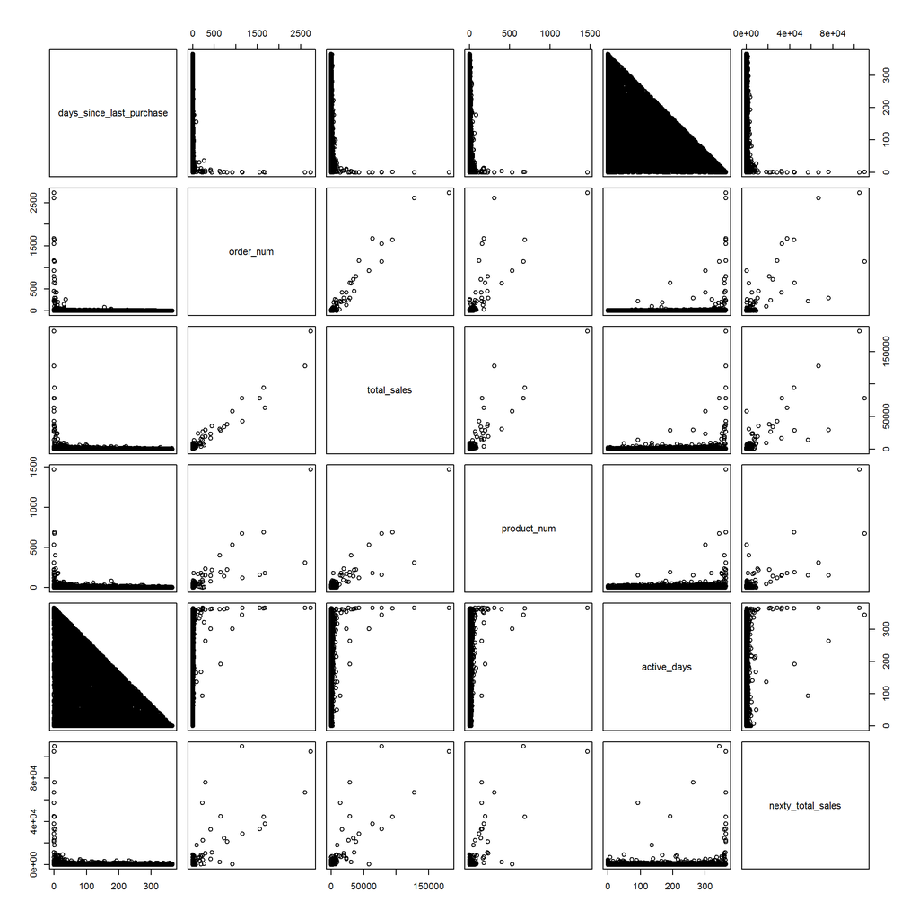

```r
pairs(customers_2012[, -1])
```

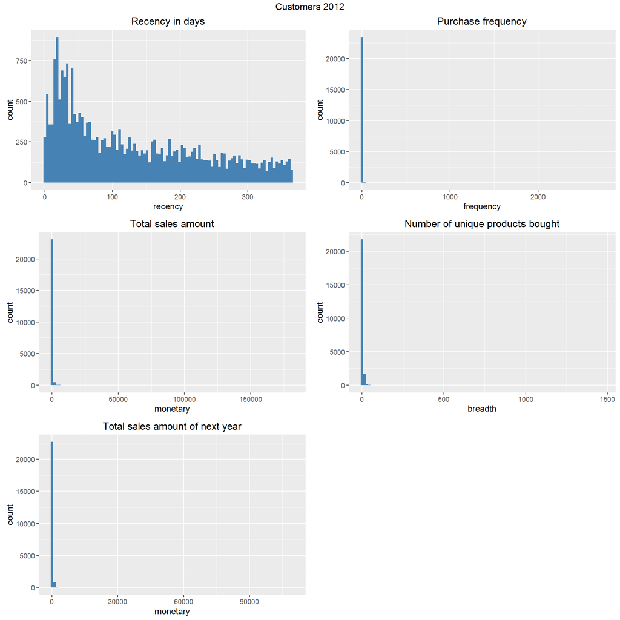

```r
plotRfms(customers_2012, c(100, 100, 100, 100, 100, 100), "rfmbn", "Customers 2012")
```

If we want to fit to a linear model,

- First we transform next years revenue and see, what distribution it fits
- After that, we transform the predictors to have a linear relashionship

### Transform dependent variable

Transformation overview

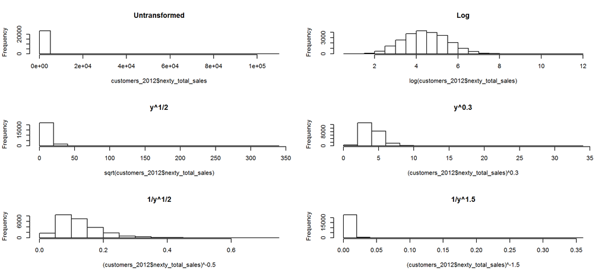

```r
par(mfrow = c(3,2))
hist(customers_2012$nexty_total_sales, main = "Untransformed")
hist(log(customers_2012$nexty_total_sales), main = "Log")
hist(sqrt(customers_2012$nexty_total_sales), main = "y^1/2")
hist((customers_2012$nexty_total_sales)^0.3, main = "y^0.3")
hist((customers_2012$nexty_total_sales)^-0.5, main = "1/y^1/2")
hist((customers_2012$nexty_total_sales)^-1.5, main = "1/y^1.5")
```

```r
par(mfrow = c(1,1))
```

We can see, that after log transformations (and after some others too, but not that clearly), the distribution got closer to normal Let’s test that!

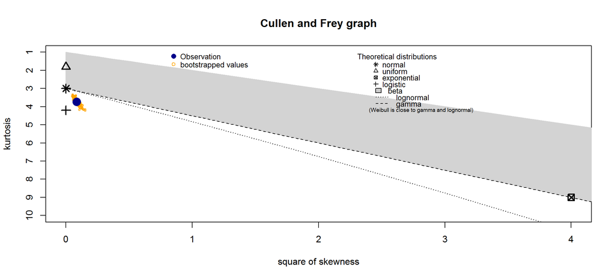

```
## summary statistics
## ------
## min:  0.6931472   max:  11.60351
## median:  4.429029
## mean:  4.446131
## estimated sd:  1.055826
## estimated skewness:  0.2918088
## estimated kurtosis:  3.728931
```

```r
log_customers_nexty_ts <- log(customers_2012$nexty_total_sales)
descdist(log_customers_nexty_ts, boot = 200)
```

Weibull and normal seems to be a good fit

```r
norm_fit <- fitdist(log_customers_nexty_ts, "norm")
weibull_fit <- fitdist(log_customers_nexty_ts, "weibull")
```

Normal fit

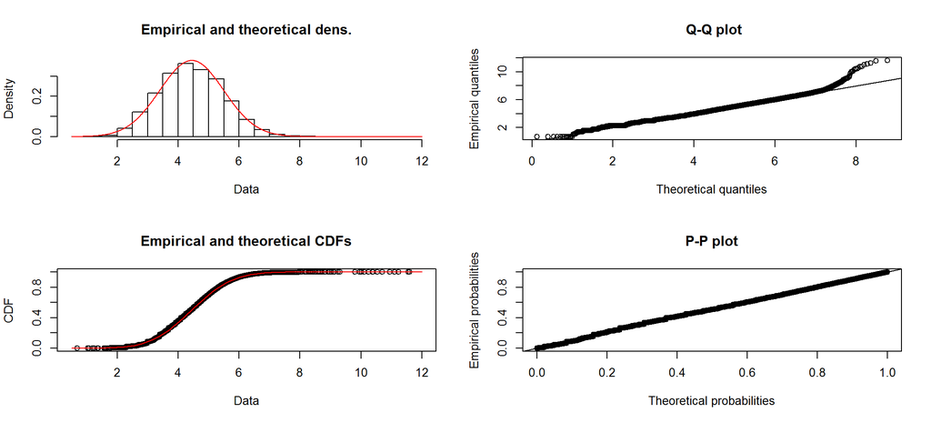

```r
plot(norm_fit)
```

```r
summary(norm_fit)
```

```
## Fitting of the distribution ' norm ' by maximum likelihood
## Parameters :
##      estimate  Std. Error
## mean 4.446131 0.006868914
## sd   1.055804 0.004857036
## Loglikelihood:  -34806.79   AIC:  69617.58   BIC:  69633.72
## Correlation matrix:
##      mean sd
## mean    1  0
## sd      0  1
```

Weibull fit

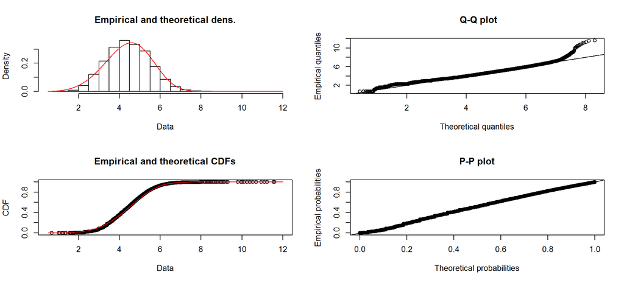

```r
plot(weibull_fit)
```

```r
summary(weibull_fit)
```

```
## Fitting of the distribution ' weibull ' by maximum likelihood
## Parameters :
##       estimate  Std. Error
## shape 4.429622 0.020688002
## scale 4.857150 0.007539542
## Loglikelihood:  -35381.61   AIC:  70767.21   BIC:  70783.35
## Correlation matrix:
##           shape     scale
## shape 1.0000000 0.3234515
## scale 0.3234515 1.0000000
```

Normal distributions seems to fit a little bit better, so we will fit for normal distribution with log link function (won’t transform the whole response)

```r
set.seed(32)
summary(l_model <- glm(nexty_total_sales ~ order_num + product_num + total_sales + days_since_last_purchase + active_days,
                       data = customers_2012,
                       family = gaussian(link = "log")))
```

```
##
## Call:
## glm(formula = nexty_total_sales ~ order_num + product_num + total_sales +
##     days_since_last_purchase + active_days, family = gaussian(link = "log"),
##     data = customers_2012)
##
## Deviance Residuals:
##    Min      1Q  Median      3Q     Max
## -11253      30      72     159   96222
##
## Coefficients:
##                            Estimate Std. Error t value Pr(>|t|)
## (Intercept)               6.546e+00  8.335e-02   78.54   <2e-16 ***
## order_num                 2.144e-03  6.884e-05   31.14   <2e-16 ***
## product_num               1.370e-03  6.571e-05   20.86   <2e-16 ***
## total_sales              -2.598e-05  1.464e-06  -17.74   <2e-16 ***
## days_since_last_purchase -2.001e-01  8.845e-03  -22.62   <2e-16 ***
## active_days               5.270e-03  2.537e-04   20.77   <2e-16 ***
## ---
## Signif. codes:  0 '***' 0.001 '**' 0.01 '*' 0.05 '.' 0.1 ' ' 1
##
## (Dispersion parameter for gaussian family taken to be 1078668)
##
##     Null deviance: 4.8593e+10  on 23625  degrees of freedom
## Residual deviance: 2.5472e+10  on 23620  degrees of freedom
## AIC: 395245
##
## Number of Fisher Scoring iterations: 14
```

… and use the Boxcox transformation on this model

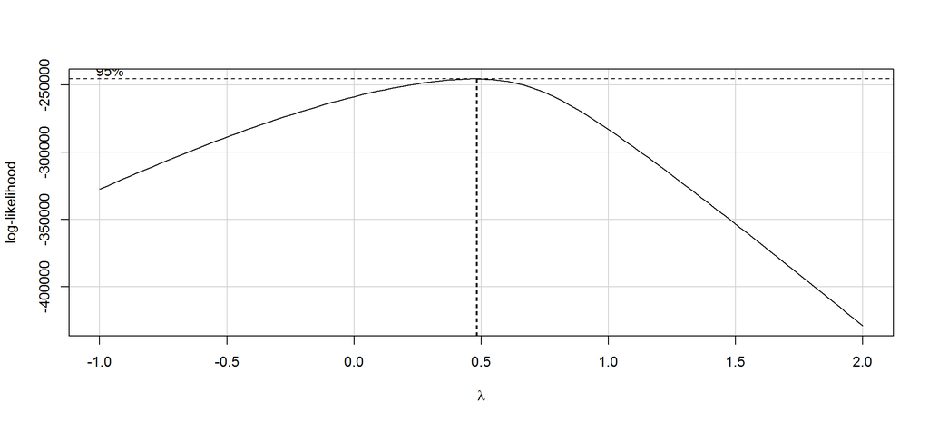

```r
boxCox(l_model, lambda = seq(-1, 2, 1/10), plotit = TRUE)
```

As it turns out, for this model, the best lambda is around 0.5

```r
nexty_lambda = 0.5
customers_2012_dep_transformed <- data.frame(customers_2012[, -c(1, 7)], nexty_total_sales = bcPower(customers_2012$nexty_total_sales, nexty_lambda))
```

### Transform independent variables

We can see from the pairs, that order_num, product_num and total_sales are somewhat linear, but really centered, active_days needs probably a < 1 power and days_since_last_purchase needs probably also a power < 1

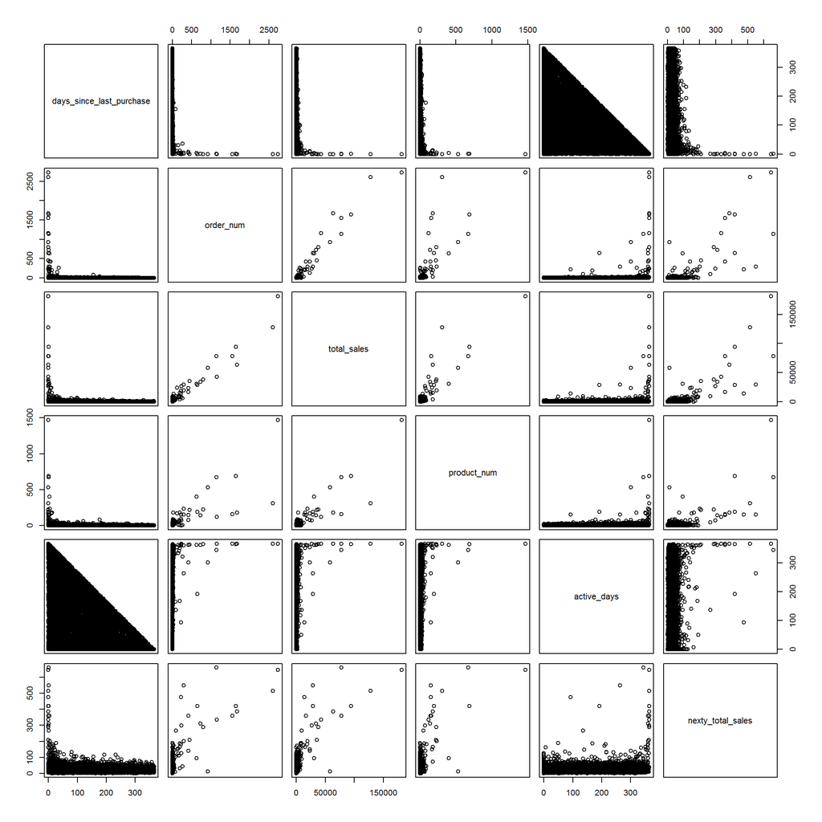

```r
pairs(customers_2012_dep_transformed)
```

Let’s calculate lambdas with the Box-Tidweel transformation In order to do that, we add 1 to recency and tenure, so all the independent variables only contain positive values

```r
customers_2012_dep_transformed$days_since_last_purchase <- customers_2012_dep_transformed$days_since_last_purchase + 1
customers_2012_dep_transformed$active_days <- customers_2012_dep_transformed$active_days + 1
```

Unfortunatelly, we can’t express the log link in this transformation, so we will use the default, identity link Since our predictors are highly corralted, we will do the transformation separately for product_num

```r
set.seed(32)
# Box-Tidwell for days_since_last_purchase + active_days  + order_num + total_sales
bt_ <- boxTidwell(nexty_total_sales ~ days_since_last_purchase + active_days  + order_num + total_sales,
                                data = customers_2012_dep_transformed)
lambda_ <- bt_$result[, 3]
print(bt_)
```

```
##                          Score Statistic   p-value MLE of lambda
## days_since_last_purchase       3.2928677 0.0009917    -0.6829335
## active_days                   -0.4324392 0.6654222     0.3097800
## order_num                     -8.5975593 0.0000000     1.8143237
## total_sales                  -27.1297023 0.0000000     0.7464798
##
## iterations =  20
```

```r
# Box-Tidwell for product_num
bt_product_num <- boxTidwell(nexty_total_sales ~ product_num,
                              data = customers_2012_dep_transformed)
lambda_product_num <- bt_product_num$result[, 3]
print(bt_product_num)
```

```
##  Score Statistic p-value MLE of lambda
##        -35.36252       0     0.8059249
##
## iterations =  5
```

Transform the variables

```r
customers_2012_transformed <- data.frame(days_since_last_purchase = (customers_2012_dep_transformed$days_since_last_purchase)^lambda_[1],
                                         order_num = (customers_2012_dep_transformed$order_num)^lambda_[3],
                                         total_sales =  (customers_2012_dep_transformed$total_sales)^lambda_[4],
                                         product_num = (customers_2012_dep_transformed$product_num)^lambda_product_num,
                                         active_days = (customers_2012_dep_transformed$active_days)^lambda_[2],
                                         nexty_total_sales = customers_2012_dep_transformed$nexty_total_sales)
```

## Train and test

### Clean data: Discarde points with too high leverage, influence

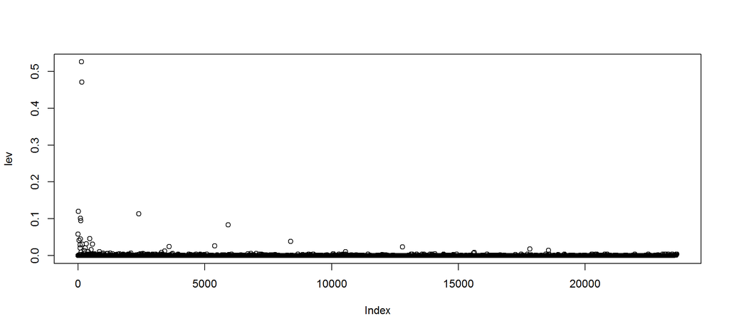

```r
# Train the model
set.seed(32)
l_model <- glm(nexty_total_sales ~ order_num + product_num + total_sales + days_since_last_purchase + active_days,
                       data = customers_2012_transformed,
                       family = gaussian(link = "log"))

lev <- hat(model.matrix(l_model))
plot(lev)
```

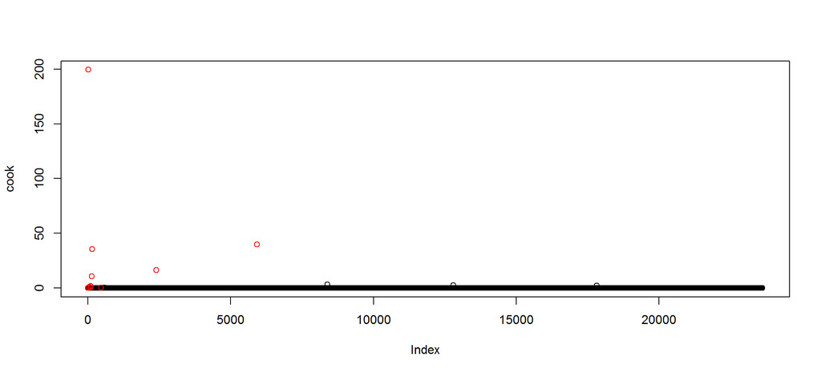

```r
high_leverage_points <- as.numeric(row.names(customers_2012_transformed[lev > 0.04,]))

cook <- cooks.distance(l_model)
plot(cook)
points(high_leverage_points, cook[high_leverage_points], col = 'red')
```

```r
high_influence_points <- as.numeric(row.names(customers_2012_transformed[cook > 10,]))

outliners <- union(high_influence_points, high_leverage_points)
```

As we can see, the outliners are mostly the high valued customers

```r
customers_2012_transformed[outliners,]
```

```
##      days_since_last_purchase  order_num total_sales product_num
## 4                   1.0000000  615616.80    4483.835    59.45122
## 135                 1.0000000 1716326.47    8420.749   356.76458
## 144                 1.0000000 1572073.92    6484.229   101.82406
## 2393                0.6228974  350615.68    4486.714   189.95350
## 5922                1.0000000  240264.13    3602.103   157.59316
## 2                   0.3331578  119235.20    2247.363   126.05139
## 41                  1.0000000  359610.67    2868.872    47.70552
## 86                  0.6228974  681911.03    5167.097   194.27015
## 97                  1.0000000   20819.66    2011.690    31.04382
## 106                 1.0000000  704683.27    3841.383    65.40792
## 456                 1.0000000   64868.43    2488.853    77.51828
##      active_days nexty_total_sales
## 4       6.224653         359.95127
## 135     6.224653         645.45542
## 144     6.224653         515.18399
## 2393    6.111750         659.75808
## 5922    5.864844          12.74042
## 2       6.203499          93.64141
## 41      6.224653         335.13018
## 86      6.219379         419.48257
## 97      6.224653         298.29492
## 106     6.224653         386.99357
## 456     6.214096         209.14876
```

```r
customers_2012_pp <- customers_2012_transformed[-outliners,]
```

### Train

```r
set.seed(3456)
trainIndex <- createDataPartition(customers_2012_pp$nexty_total_sales, p = .8,
                                  list = FALSE,
                                  times = 1)

customer_purchase_train <- customers_2012_pp[ trainIndex,]
customer_purchase_test  <- customers_2012_pp[-trainIndex,]

set.seed(32)
summary(l_model <- glm(nexty_total_sales ~ order_num + product_num + total_sales + days_since_last_purchase + active_days,
                       data = customer_purchase_train,
                       family = gaussian(link = "log")))
```

```
##
## Call:
## glm(formula = nexty_total_sales ~ order_num + product_num + total_sales +
##     days_since_last_purchase + active_days, family = gaussian(link = "log"),
##     data = customer_purchase_train)
##
## Deviance Residuals:
##      Min        1Q    Median        3Q       Max
## -111.455    -8.179    -2.739     4.939   228.041
##
## Coefficients:
##                            Estimate Std. Error t value Pr(>|t|)
## (Intercept)               2.764e+00  8.238e-03  335.48   <2e-16 ***
## order_num                -1.131e-05  2.578e-07  -43.86   <2e-16 ***
## product_num               7.893e-03  7.830e-04   10.08   <2e-16 ***
## total_sales               1.448e-03  2.477e-05   58.44   <2e-16 ***
## days_since_last_purchase  5.761e-01  2.815e-02   20.46   <2e-16 ***
## active_days               2.605e-02  2.342e-03   11.12   <2e-16 ***
## ---
## Signif. codes:  0 '***' 0.001 '**' 0.01 '*' 0.05 '.' 0.1 ' ' 1
##
## (Dispersion parameter for gaussian family taken to be 148.0256)
##
##     Null deviance: 3995494  on 18892  degrees of freedom
## Residual deviance: 2795751  on 18887  degrees of freedom
## AIC: 148040
##
## Number of Fisher Scoring iterations: 7
```

### Test

```r
fitted_l_model <- cbind(customer_purchase_test[], predict(l_model, customer_purchase_test, se.fit = T, type = "response"))
```

Inverse bc transformation for dependent variable and getting actual values from untransformed data (without outliners)

```r
fitted_l_model$nexty_total_sales <- customers_2012[-outliners,][-trainIndex,]$nexty_total_sales
fitted_l_model$fit <- invBcPower(fitted_l_model$fit, nexty_lambda)
```

When we plot the fit, we can see, that there is 1 point, where the difference is really high

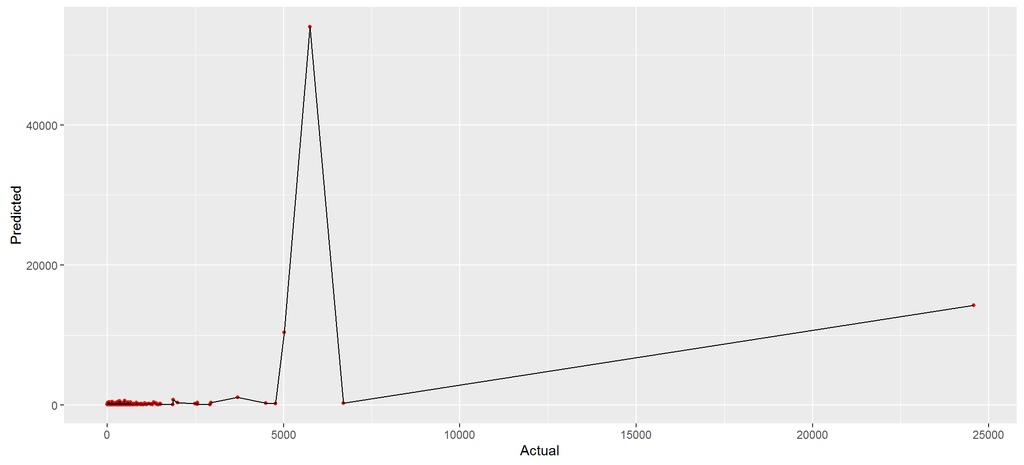

```r
fitted_l_model <- within(fitted_l_model, {
  LL <- fit - 10 * se.fit
  UL <- fit + 10 * se.fit
})

ggplot(fitted_l_model, aes(nexty_total_sales, fit)) +
  geom_point(size = 1, color = 'red') +
  geom_ribbon(aes(ymin = LL, ymax = UL), alpha = .25) +
  geom_line(aes(nexty_total_sales, fit)) +
  labs(x = "Actual", y = "Predicted")
```

Let’s remove the point for the plot and see, whether the other predicted values are correct or not We can see, that there are still some points, that still is really far from a y = x line

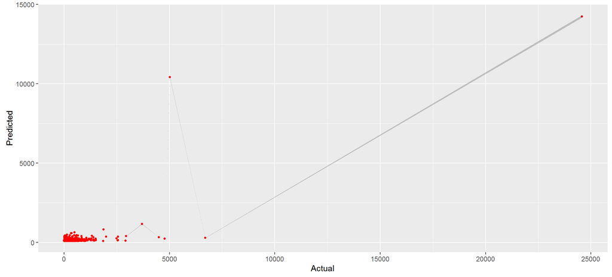

```r
fitted_l_model_cleaned <- fitted_l_model %>%
  filter(se.fit != max(se.fit))
ggplot(fitted_l_model_cleaned , aes(nexty_total_sales, fit)) +
  geom_point(size = 1, color = 'red') +
  geom_ribbon(aes(ymin = LL, ymax = UL), alpha = .25) +
  labs(x = "Actual", y = "Predicted")
```

#### Differences and RMSE

Note: the model didn’t contains the outliners

```r
print(test_RMSE <- calculateRMSEFromFit(fitted_l_model))
```

```
## [1] 758.6615
```

```r
print(test_diff <- calculateDiffFromModel(fitted_l_model))
```

```
## [1] -100377.9
```

```r
print(test_diff_perc <- calculateDiffFromModel(fitted_l_model) * 100 / sum(fitted_l_model$nexty_total_sales))
```

```
## [1] -13.77928
```

Without the highly unaccurate point

```r
print(calculateRMSEFromFit(fitted_l_model_cleaned))
```

```
## [1] 285.816
```

```r
print(calculateDiffFromModel(fitted_l_model_cleaned))
```

```
## [1] -148670.4
```

```r
print(calculateDiffFromModel(fitted_l_model_cleaned) * 100 / sum(fitted_l_model_cleaned$nexty_total_sales))
```

```
## [1] -20.57096
```

Unfortunatelly, we can see from the plot and the error measures, that the transformation of the predictors and the dependent data did not help much in refining the model, so we won’t investigate this approach further

Save training and test results

```r
glm_results <- createModelSummary(description = "Gaussian linear regression with log link, Boxcox transformation of dependent and Box-Tidwell transformation of independent variables, formula = nexty_total_sales ~ order_num + product_num + total_sales + days_since_last_purchase + active_days",
                                   test_RMSE = test_RMSE,
                                   test_diff = test_diff,
                                   test_diff_percent = test_diff_perc)
saveRDS(glm_results, file = "data/results/glm_log.rds")
```